# Correlation Inquiry of a Data Set

Ozgur Kaan Varlik - IE360 - Fall 2020

## Introduction

In the field of economics, inflation is defined as a general rise in the price level over a period of time, which consequently results in a diminished purchasing power. If there is an increase in the price level, the same amount of money will not be able to buy the same set of items, since each unit of money has a lower value compared to before. On the other hand, Consumer Price Index (CPI) reflects the weighted average of prices of a basket of consumer goods and services, such as transportation, food, and medical care. It is a highly preferred method for assessing the inflation rate, although there has always been some dispute whether CPI is actually a good measure of inflation or not.

An exchange rate is the value of a nation’s currency against the currency of another. “How is this related to consumer price index?”, one might wonder. The answer lies within the measures taken by the central bank after a rise or decrease in the inflation rate. Usually when inflation is low, interest rates are reduced and when inflation is high, interest rates are raised by the central bank of that country. This consequently results in a change in the behavior of the average consumer. If interest rates are raised, households are more likely to keep their money in the bank because of higher returns. Similarly, if you get a higher interest rate for a certain currency, you are more likely to invest there. On the other hand, low inflation means reduced interest rates and as a result, less people are inclined to invest in that currency.

Another aspect to consider is the amount of consumer bank loans. What is expected to happen when inflation is high? When there is an increase in inflation, the central bank, as I have stated above, raises interest rates. This creates an opportunity for lenders, in that, higher interest rates mean higher returns, also since the cost of living is rising, more and more people are inclined to get a bank loan. However, borrowers might benefit from this situation too. Because in a country with ever-increasing inflation, each loan you get is going to be worth less and less over time. So it might actually be good idea after all, especially in a country such as Turkey.

It might also be useful to take the unemployment rate of a country and compare it to the consumer price index. It is said in economics that low inflation and high employment are the the cornerstones of monetary policy. However, there seems a tradeoff between inflation and unemployment, which is explained by the “Phillips Curve”. It shows that there should in fact be an inverse relationship between the two. When inflation is high, unemployment should be low and when unemployment is high, inflation should be low. Nevertheless, this idea does not hold for the long-term as the economy can adjust to any rate of inflation and return to the natural rate of unemployment. However, there have been several cases that proved this idea wrong and maybe a little too simple. One of the cases is the United States, which has experienced low unemployment and inflation over the last decade and the other is Turkey, which we will take a look in a moment, a completely different story.

As you can see, all the terms I have used, namely consumer price index, the exchange rate, consumer bank loans and the unemployment rate, appear to be related in theory. Today I will put this idea to the test in order to see if it holds up in reality. So, the question I am trying to answer today is:

**Is consumer price index actually related to the exchange rates, consumer bank loans and the unemployment rate?**

To be able to at least properly look into this question, we will make some visual analyzes, do some tests for linear relationships and then interpret the results.

## Manipulation and Visualization

The set of data I have used for this assignment was easy to work with, since they are from the same source.

```
##          Date Exchange Rate Bank Loans    CPI Unemployment Rate
## 1: 2013-01-01         1.764  196419481 216.74               9.7
## 2: 2013-02-01         1.770  200170903 217.39               9.7
## 3: 2013-03-01         1.807  206280095 218.83               9.4
## 4: 2013-04-01         1.796  210404281 219.75               8.7
## 5: 2013-05-01         1.823  217536905 220.07               8.2
## 6: 2013-06-01         1.895  223771760 221.75               8.1
```

I have also added a column to specify the year in order to group the values in a less complicated way.

**Now, let’s visually inspect our set of data:**

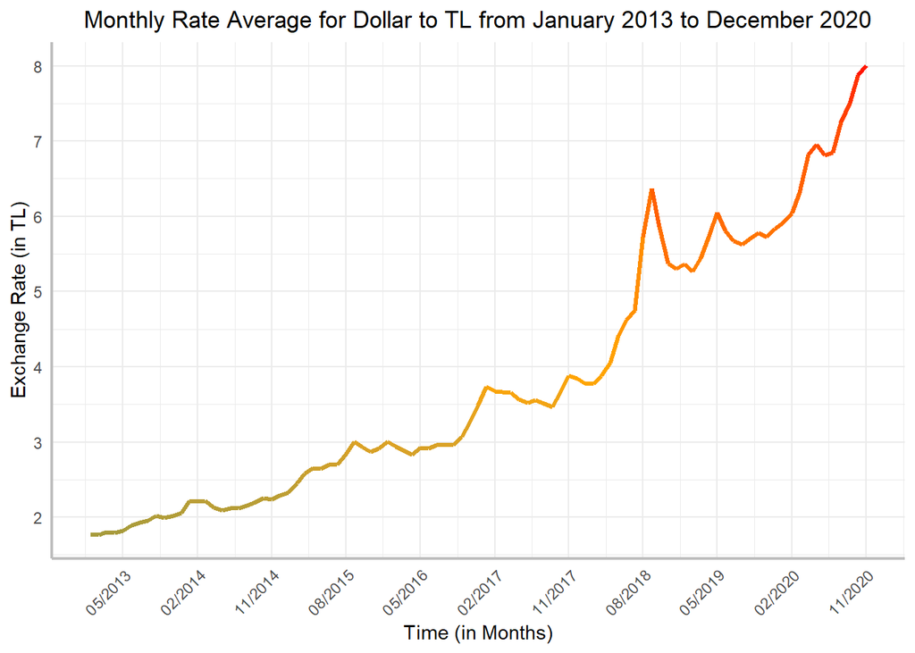

At first glance, one can easily say that there is an increasing trend, which has gotten more severe over the years. There seems to be a rapid increase followed by a rapid decrease in 2018. This is most probably due to mistrust in the economy and the elections at the time.

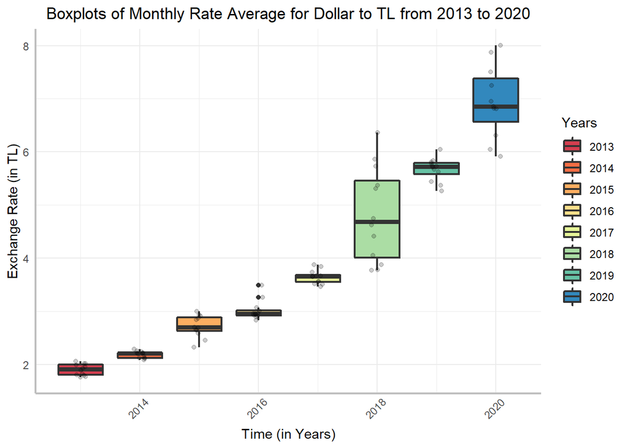

Further inspection of the boxplots supports our argument of the ever-increasing trend. As one can see, in the last three years, the data is more scattered, whereas in early years boxplots are more condensed, meaning the exchange rate has increased more significantly over the last several years compared to the early 2010s.

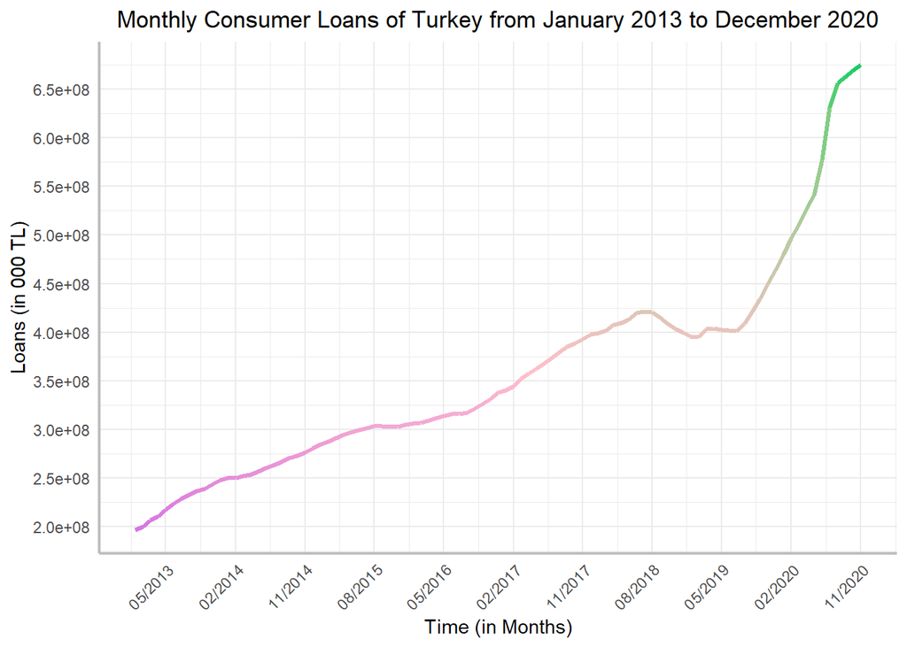

The line graph of monthly consumer loans seem to be not irrelevant to the exchange rate after all. We can see a similar increasing trend that is getting more rapid coupled with an abnormality in 2018 just like what happened with the exchange rate.

**However, it might be interesting to take a look at the boxplots:**

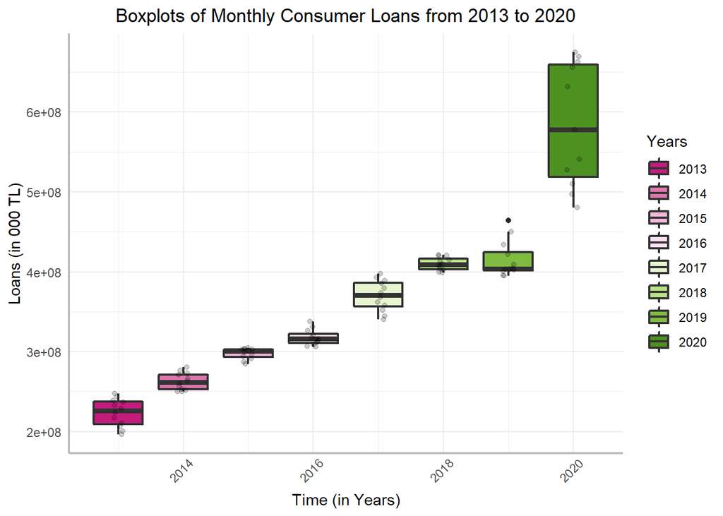

The boxplots appear to support our argument of similarity, in that we can still see an increasing trend with the last couple of years being more scattered. However, one should notice that the rise seems to have happened more rapidly here.

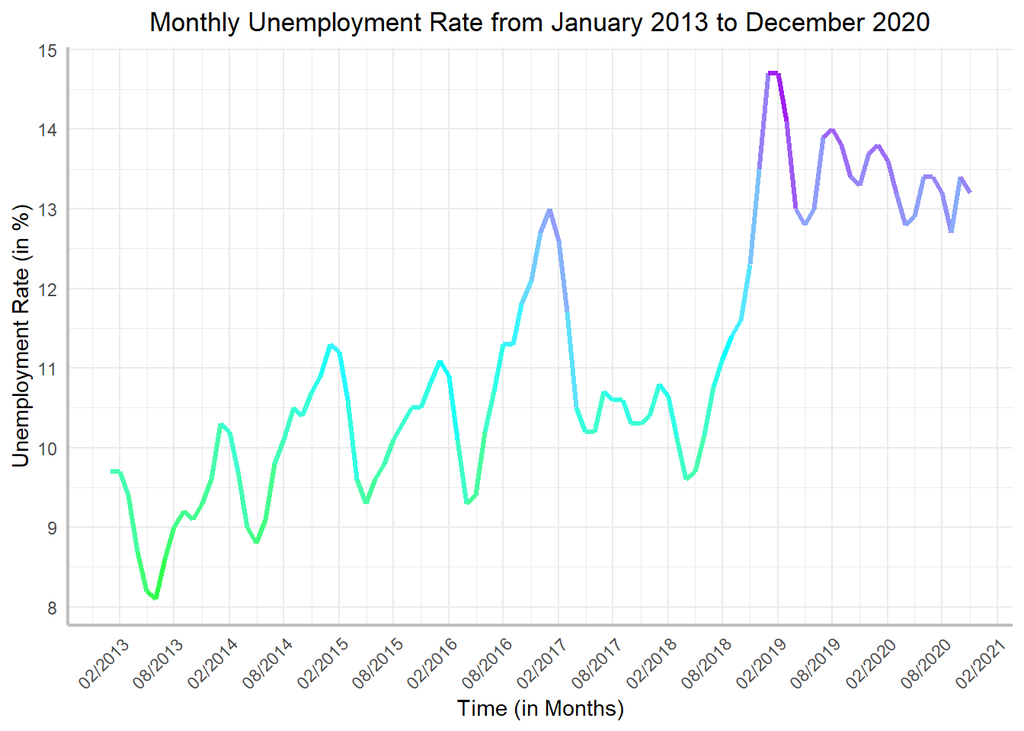

By looking at the line graph of the unemployment rate over the years, one can easily say that this set of data is not as similar to the other ones. It seems to have significantly more fluctuations, almost in a seasonal pattern, peaking in winter and plummeting in summer. However, it is worth mentionaing that there appears to be a slow but icreasing trend.

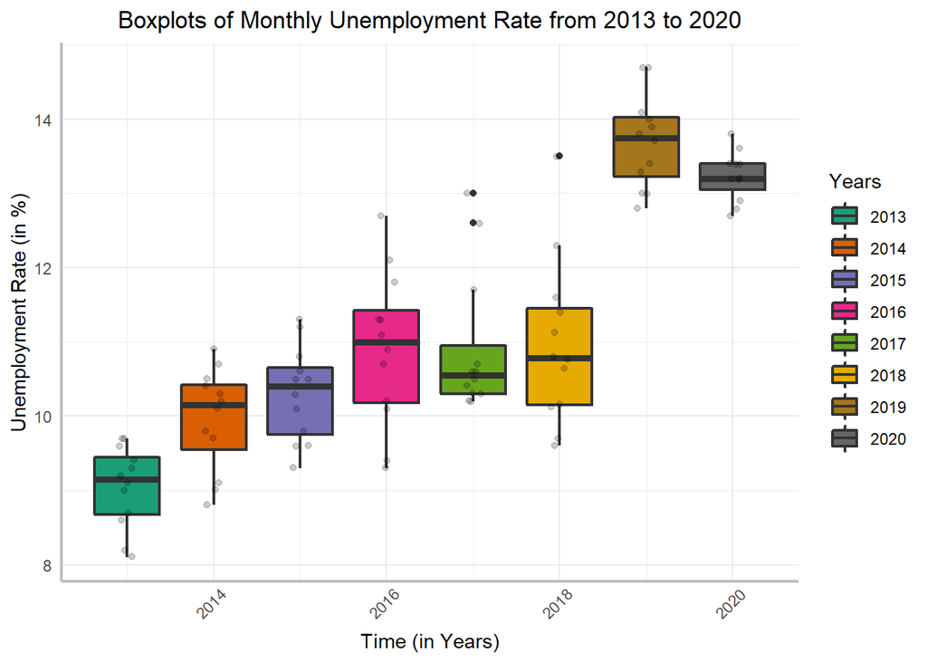

When we look at the boxplots, they show that there is indeed an increasing trend, however, unlike the measures above, the boxplots are not condensed like in early years. So it is safe to say that the correlation between the unemployment rate and the exchange rate will not be as high as the correlation between the exchange rate and consumer loans.

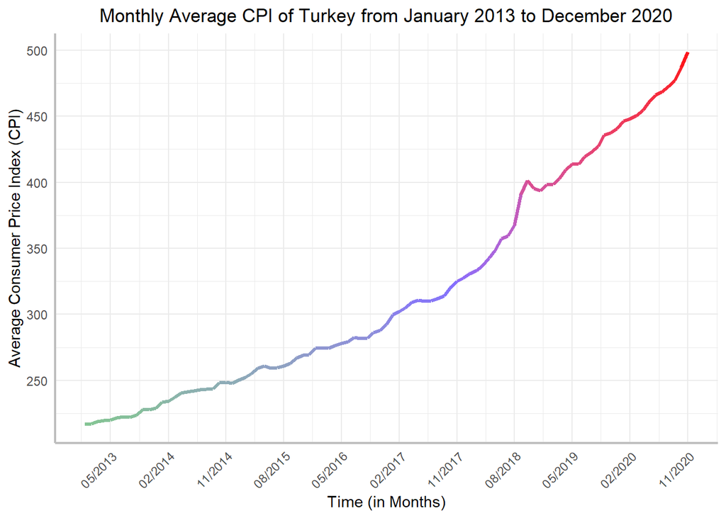

What should immediately be noticed when taking a look at this graph and the ones above is that average CPI definitely share similarities with the other measures, especially with the exchange rate and consumer loans. Like in all other graphs, we can see an increasing trend and there seems to have happened an unsual increase and decrease in 2018 just like our with our first two measures.

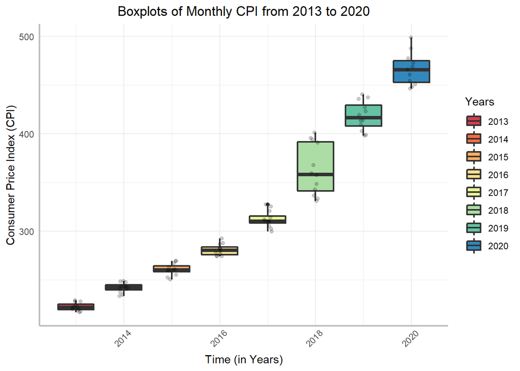

The boxplots for the consumer price index over the years do not tell a different story. In fact, the boxplots for the exchange rate seem to have very similar visual properties compared to the CPI.

After making our visual inspection and finding several similarities, let’s now see if there in fact is any correlation between these measures.

## Correlation Analysis

There are different method to perform correlation analysis, I will be using Pearson correlation coefficient (r) for my set of data. It is a measure for determining the level of linear independence between two variables. The values r can take range from -1 to 1. If r = 1, it means that there is a positive correlation between the variables, in that for every positive increase in one variable, we would also expect a positive increase in the other variable. If r = -1, similarly, it means that there is a negative correlation between the variables, in that for every increase in one variable, we would expect a decrease in the other variable. If r = 0, it means there is no correlation, in that they are not related.

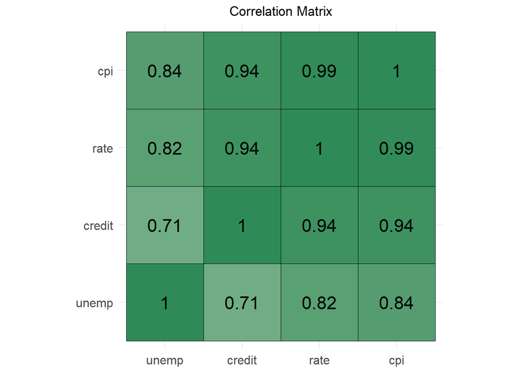

By building a correlation matrix, we are now able to see if our measures are in fact related. At first glance, it can be said that there is a high degree of correlation between CPI and the exchange rate, which proves our argument above in fact right. It also appears that the correlation between CPI and consumer loans is relatively high, whereas the lowest correlation is obtained by comparing the unemployment rate with consumer loans.

**Now, let’s do some of these tests separately to make further observations:**

We will be using Pearson Correlation Test for our analysis. Our null hypothesis states that there is zero or an insignificant level of correlation between the variables, whereas our alternative hypothesis states that there is a significant level of correlation between the variables. If our p-value is less then 0.05, we will be rejecting our null hypothesis and therefore conclude that there is in fact a degree of correlation between the variables.

```
##
##  Pearson's product-moment correlation
##
## data:  Data_for_hw2$rate and Data_for_hw2$cpi
## t = 64.886, df = 93, p-value < 2.2e-16
## alternative hypothesis: true correlation is not equal to 0
## 95 percent confidence interval:
##  0.9836947 0.9927667
## sample estimates:
##      cor
## 0.989135
```

The result of Pearson correlation test between the exchange rate and CPI shows that there is in fact a significant level of correlation between the two, since the p-value very low. We can say that CPI and the exchange rate is positively correlated.

```
##
##  Pearson's product-moment correlation
##
## data:  Data_for_hw2$credit and Data_for_hw2$cpi
## t = 26.089, df = 93, p-value < 2.2e-16
## alternative hypothesis: true correlation is not equal to 0
## 95 percent confidence interval:
##  0.9080936 0.9583457
## sample estimates:
##       cor
## 0.9379695
```

A similar result can be seen here. The result of the correlation test shows that we can reject our null hypothesis and conclude that CPI and consumer loans are positively correlated, since the p-value is very low.

```
##
##  Pearson's product-moment correlation
##
## data:  Data_for_hw2$unemp and Data_for_hw2$cpi
## t = 14.68, df = 93, p-value < 2.2e-16
## alternative hypothesis: true correlation is not equal to 0
## 95 percent confidence interval:
##  0.7627294 0.8877888
## sample estimates:
##       cor
## 0.8357921
```

Although results from this test is relatively more interesting, we still reject our null hypothesis and conclude there is a significant level of positive correlation between CPI and the unemployment rate.

**As for the next step of our inspection, let’s now fit a regression line to visually analyze the level of correlation:**

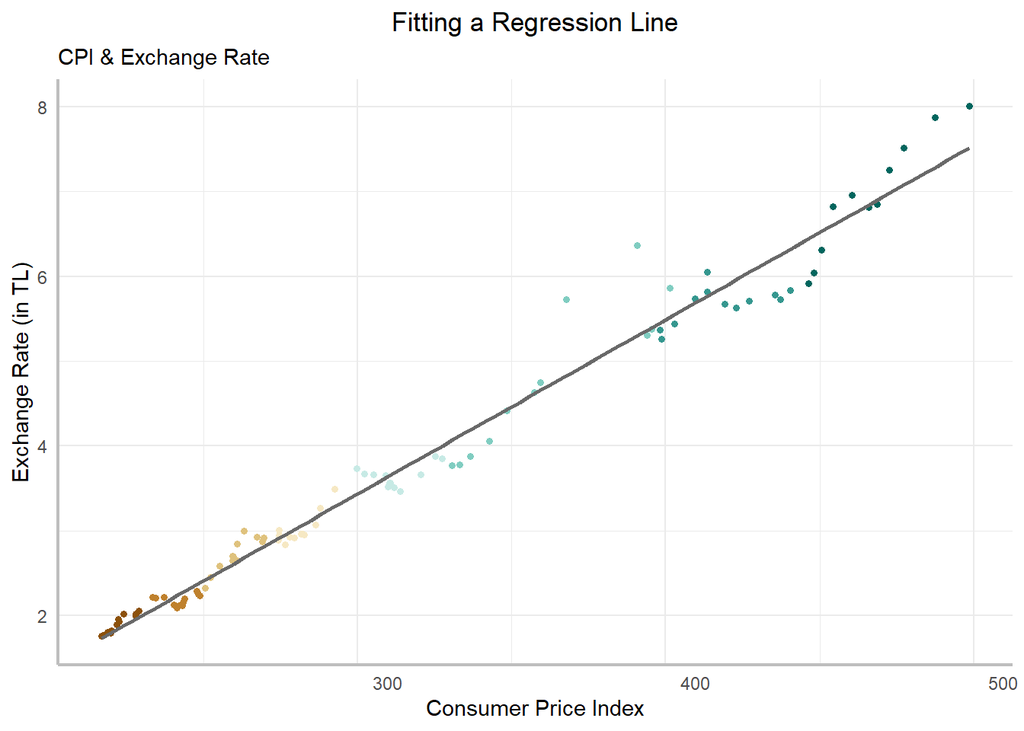

As one can see, the variables are highly, and positively, correlated, in that the regression line could be fitted easily with minor errors.

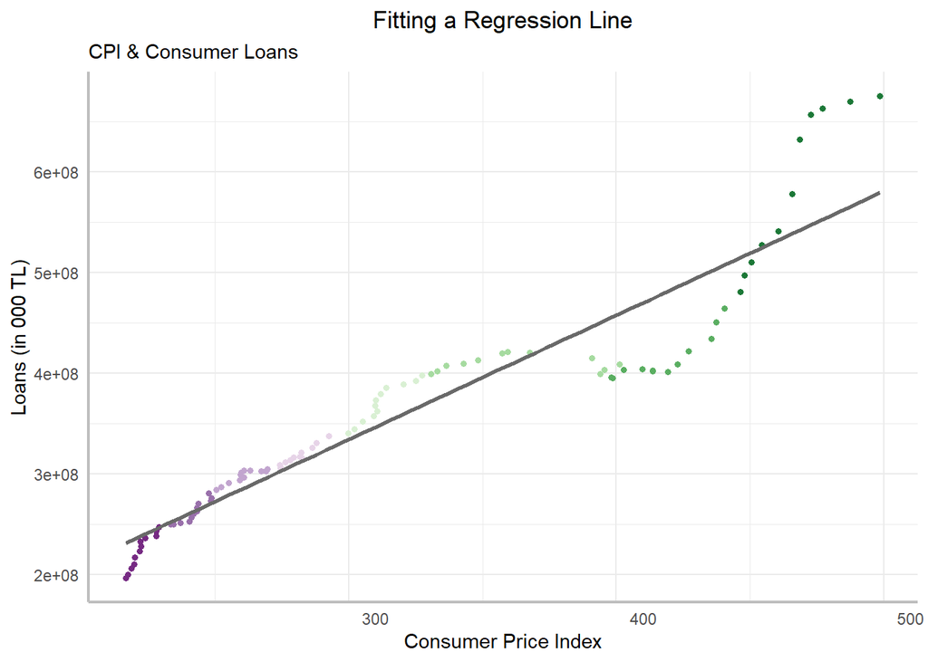

Although the level of correlation seems to be lower, one cannot argue against it. However, it is worth mentioning that over the last several years the variables appear to have become less correlated, it may be wise to test the variables for after 2018.

```
##
##  Pearson's product-moment correlation
##
## data:  newset$credit and newset$cpi
## t = 7.3745, df = 33, p-value = 1.807e-08
## alternative hypothesis: true correlation is not equal to 0
## 95 percent confidence interval:
##  0.6181616 0.8885462
## sample estimates:
##       cor
## 0.7888955
```

It appears that our assumption is correct to some extent, in that the correlation coefficient is significantly lower, but one should also keep in mind that our set of data is much smaller.

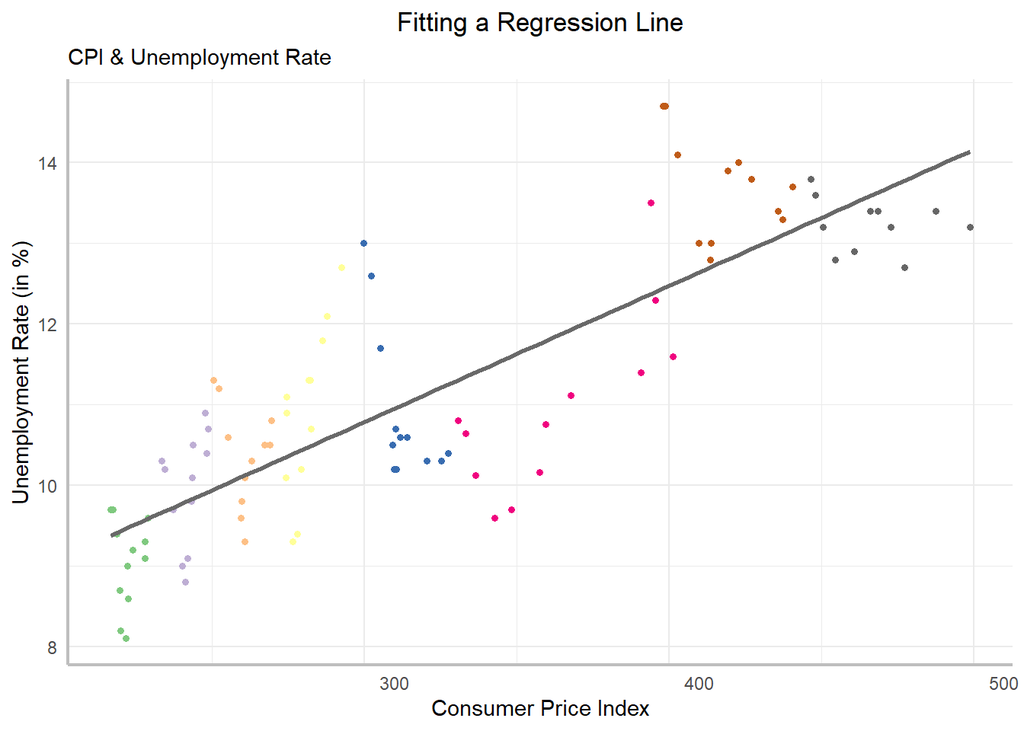

As we have seen from the correlation test, the level of correlation between CPI and the unemployment rate is lower than the other two and here one can visually validate this result. The errors will be significantly higher in this graph than the other two above, since the values are much more scattered.

**Finally, it might also be good idea to fit our data in a multiple linear regression model to see if our measures, the exchange rate, consumer loans and the unemployment rate, can work together to predict the behavior of consumer price index:**

```
##
## Call:
## lm(formula = cpi ~ rate + credit + unemp, data = Data_for_hw2)
##
## Residuals:
##     Min      1Q  Median      3Q     Max
## -33.107  -4.913   0.287   6.414  25.603
##
## Coefficients:
##              Estimate Std. Error t value Pr(>|t|)
## (Intercept) 8.506e+01  1.242e+01   6.846 8.65e-10 ***
## rate        3.896e+01  2.567e+00  15.175  < 2e-16 ***
## credit      7.813e-08  3.344e-08   2.337   0.0216 *
## unemp       5.122e+00  1.256e+00   4.076 9.77e-05 ***
## ---
## Signif. codes:  0 '***' 0.001 '**' 0.01 '*' 0.05 '.' 0.1 ' ' 1
##
## Residual standard error: 11.24 on 91 degrees of freedom
## Multiple R-squared:  0.982,  Adjusted R-squared:  0.9814
## F-statistic:  1652 on 3 and 91 DF,  p-value: < 2.2e-16
```

By looking at the summary of the model, we can say that the measures did indeed deliver consistent outcomes with our observations so far. By looking at the p-value of the F-Test, we can conclude that there is at least one significant linear relationship between CPI and the other variables. Our R-squared value is pretty close to 1, which also supports this argument. Furthermore, the p-values of the T-Test can also be interpreted as the indication of a significant linear relationship between the variables, since all of them are lower than 0.05.

## Conclusion

My analysis of this data set has started with a visual inspection. Although it is not scientific by any means, it was a good starting point to see if there is anything visible that would lead me to believe that these variables are correlated, and in fact there were some similarities like the increasing trend and the abnormalities in the year 2018 that did support my initial assumption. Then I continued with finding correlation coefficients & p-values of the the variables by using the Pearson Correlation Test, and by the end of our tests, it appeared that we were indeed right and there was analytically a significant level of correlation between the variables. Next, I fitted a regression line in the scatter plots of our measures to once again visually inspect if there is anything to consider or validate. Our visual analysis suggested that the results from the tests do conform with the regression line fittings. Finally, I fitted our data into a linear regression model to look for any abnormalities or different outcomes, but there weren’t any. The results were consistent with our assumptions before.

Although we have concluded that our variables seem to be significantly correlated, one should consider that there are many other factors affecting these variables. For example, exchange rates are affected by inflation rates (of both countries), interest rates, government debts, speculations and much more. On the other hand, inflation does get affected by supply, demand, cost of production, wages etc. So it would be wise to say that our analysis is very very simple compared the real world and we shouldn’t directly conclude that our measures are 100% related. ıt is worth mentioning how different outcomes are yielded when comparing the the unemployment rate with CPI. Because consumer price index is used as a measure of inflation and we have the unemployment rate to compare it with, when unemployment rate is fluctuating, we would expect CPI to decelerate, since unemployment rate and inflation rate are in theory inversely correlated. However, our analysis told a different story. Although we saw unemployment rate drop and rise over the years several times, it seems that CPI was increasing more and more rapidly. This might be due to the CPI not being the best indicator of inflation, the country’s ongoing economical struggle or the fact that long term data is not well explained by the Phillips Curve.

### You can reach the R Markdown file of my work by clicking [**here**](https://github.com/BU-IE-360/fall20-ozgurkv/blob/master/Files/HW2.Rmd).